# h1&h2models for neuroethical judgments

Kianté Fernandez

5/22/2020

To follow what I did below the code directly below puts the data in the format I used to test for beta differences and condition differences.

I realized that the code i sent is in long format, but you can make it ‘longer’ in the sense that we take each of the beta’s and create an id variable (either risk, gain, or interaction).

These two will put the data in the long format with `type` being each beta and `Beta` being the values extracted from the logistic reg.

Import data and exclude outliers (i.e, subs with extreme risk or benefit weights relative to the sample (need to find a SD criterion))

```r
#import the csv I sent here and call it data
data <- read.csv("longFormat.csv", header = TRUE) %>%  filter(user_id != "FIvIqXVg") %>%   filter(user_id != "tTZWd9tg") %>%  filter(user_id != "ZJ8tICU0") %>%   filter(user_id != "4lsMLrPn") %>%  filter(user_id != "0XnbWTTY")
```

```r
#long format
data.h1.long <-distinct(dplyr::select(data,
               user_id, Risk_Beta, Gain_Beta, Interaction_Beta)) %>%
  melt(id = "user_id", variable.name = "type", value.name = "Beta")

#h2 data long
data.h2.long <- distinct(dplyr::select(data,
                user_id ,condition, trial_index,  Risk_Beta , Gain_Beta , Interaction_Beta)) %>%
  melt(id = c("user_id","condition", "trial_index"),
                       variable.name = "type",
                       value.name = "Beta")
```

## H1

This is how I would go about testing our first aim:

### JDM: This is good- the only thing we want to know before these models is whether the risk/benefit effects are significantly greater than 0. So, I would just add a one sample t-test for each of risk, benefit & neutral. If Neutral is not sig. dif. from 0, that’s a quantitative reason to drop it. Then, go ahead and test whether risk and benefit are dif. from each other like you do here.

```r
#I take a subset of the data to disclude the interaction betas because we are only testing risk and gain differences
subset <- subset(data.h1.long, type != "Interaction_Beta")

# Sort by beta type then user_id so that the t test function reads it
subset <- subset[order(subset$type, subset$user_id), ]

# Paired t-test
t.test(Beta ~ type, subset, paired=TRUE)
```

```
##
##  Paired t-test
##
## data:  Beta by type
## t = -8.7994, df = 338, p-value < 2.2e-16
## alternative hypothesis: true difference in means is not equal to 0
## 95 percent confidence interval:
##  -1.0619387 -0.6739094
## sample estimates:
## mean of the differences
##               -0.867924
```

```r
#said another way...(you can 'never' look at something in too many ways...)
#t.test(data$Risk_Beta - data$Gain_Beta, mu=0, var.equal=TRUE)


#Here we are including the interaction beta in the model and testing again while accounting for type being within users
aov <- aov(Beta ~ type + Error(user_id/type), data=data.h1.long)
summary(aov)
```

```
##
## Error: user_id
##            Df Sum Sq Mean Sq F value Pr(>F)
## Residuals 338    190  0.5622
##
## Error: user_id:type
##            Df Sum Sq Mean Sq F value Pr(>F)
## type        2  128.2   64.08   67.86 <2e-16 ***
## Residuals 676  638.3    0.94
## ---
## Signif. codes:  0 '***' 0.001 '**' 0.01 '*' 0.05 '.' 0.1 ' ' 1
```

```r
model.tables(aov, "means")
```

```
## Tables of means
## Grand mean
##
## 0.01853772
##
##  type
## type
##        Risk_Beta        Gain_Beta Interaction_Beta
##          -0.4002           0.4677          -0.0118
```

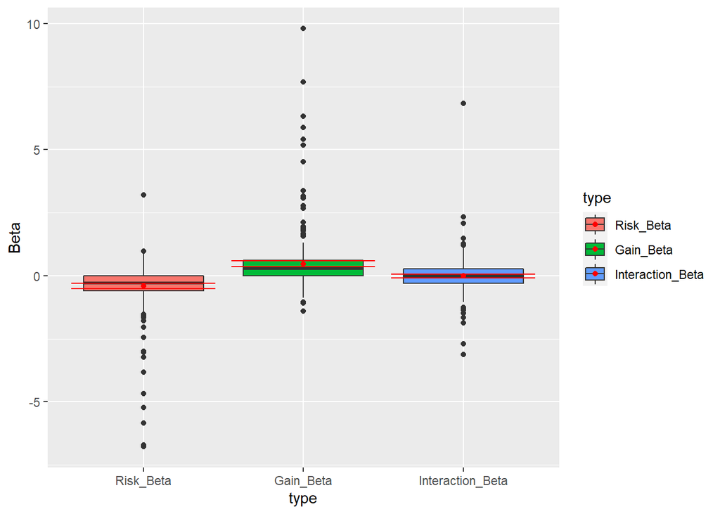

```r
#a graph with mean too!
ggplot(data.h1.long, aes(x=type, y=Beta, fill=type)) + geom_boxplot()+
  stat_summary(fun.data = mean_cl_boot, geom = "errorbar", color = "red") +
    stat_summary(fun = mean, geom = "point", color = "red")
```

So the thing about this is I actully see larger effects for gain than risk here.

Now I did meantion we have alot of people leveraging the data so I’d check my assumption. I could have also built the logistic models wrong. So I included the code for how I made those below as well (it is in the chunk titled “within subject logistic”).

## H2

Participants risk aversion to harm will change as the cognitive domain being treated changes. Specifically, participants will be more risk averse to mood, and self-control because these are more central to self-identity & physical autonomy/ability (e.g., motor).

Why would we expect that the difference in weights between harm/benefit would be moderated by cognitive domain? -Goodwin & Sun: Willingness to alter traits varies. (How did they frame it, and what were the domains?) -Enhancing, not repairing -Subjects rated themselves on traits. Asked others to rate the importance of those traits in characterizing that person. -People thought the more important things to change were less morally relevant. -I.e., reifies the idea that people don’t influence “core” characterological traits.

First, we want to split this such that we have a condition model for Risk, and a second model for Benefit. We might even just use a one-way ANOVA, then do post hoc t-tests.

One way to represent the whole data transparently is to include a table (one each for risk and benefit) with all Cognitive domains by all cognitive domans, whose elements contain the t-statistics and associated p-values for each domain.

```r
lm.null <- lm(Beta ~ 1, data=data.h2.long)
lm.0 <- lm(Beta ~ type, data=data.h2.long)

lm.1 <- lm(Beta ~ type + condition, data=data.h2.long)

lm.2 <- lm(Beta ~ type*condition, data=data.h2.long)

anova(lm.null, lm.0, lm.1, lm.2)
```

```
## Analysis of Variance Table
##
## Model 1: Beta ~ 1
## Model 2: Beta ~ type
## Model 3: Beta ~ type + condition
## Model 4: Beta ~ type * condition
##   Res.Df   RSS Df Sum of Sq        F    Pr(>F)
## 1  76274 71734
## 2  76272 62123  2    9611.4 5954.561 < 2.2e-16 ***
## 3  76266 61943  6     179.8   37.123 < 2.2e-16 ***
## 4  76254 61541 12     401.8   41.489 < 2.2e-16 ***
## ---
## Signif. codes:  0 '***' 0.001 '**' 0.01 '*' 0.05 '.' 0.1 ' ' 1
```

```r
summary(lm.2)
```

```
##
## Call:
## lm(formula = Beta ~ type * condition, data = data.h2.long)
##
## Residuals:
##     Min      1Q  Median      3Q     Max
## -6.4734 -0.3566 -0.0015  0.3052  9.2493
##
## Coefficients:
##                                                            Estimate Std. Error
## (Intercept)                                               -0.503281   0.014670
## typeGain_Beta                                              1.054649   0.020747
## typeInteraction_Beta                                       0.593228   0.020747
## conditionLanguage (spoken)                                 0.192613   0.021075
## conditionLong Term Memory                                  0.106247   0.019940
## conditionMood                                              0.181598   0.020359
## conditionMotor Function                                    0.002848   0.021193
## conditionSelf-control                                      0.032497   0.021575
## conditionShort Term (Working) Memory                       0.206804   0.022005
## typeGain_Beta:conditionLanguage (spoken)                  -0.255110   0.029805
## typeInteraction_Beta:conditionLanguage (spoken)           -0.242911   0.029805
## typeGain_Beta:conditionLong Term Memory                   -0.320642   0.028199
## typeInteraction_Beta:conditionLong Term Memory            -0.206540   0.028199
## typeGain_Beta:conditionMood                               -0.354037   0.028792
## typeInteraction_Beta:conditionMood                        -0.436940   0.028792
## typeGain_Beta:conditionMotor Function                      0.052396   0.029972
## typeInteraction_Beta:conditionMotor Function              -0.140841   0.029972
## typeGain_Beta:conditionSelf-control                       -0.119389   0.030511
## typeInteraction_Beta:conditionSelf-control                -0.190471   0.030511
## typeGain_Beta:conditionShort Term (Working) Memory        -0.263755   0.031120
## typeInteraction_Beta:conditionShort Term (Working) Memory -0.188970   0.031120
##                                                           t value Pr(>|t|)
## (Intercept)                                               -34.306  < 2e-16 ***
## typeGain_Beta                                              50.834  < 2e-16 ***
## typeInteraction_Beta                                       28.594  < 2e-16 ***
## conditionLanguage (spoken)                                  9.139  < 2e-16 ***
## conditionLong Term Memory                                   5.328 9.94e-08 ***
## conditionMood                                               8.920  < 2e-16 ***
## conditionMotor Function                                     0.134   0.8931
## conditionSelf-control                                       1.506   0.1320
## conditionShort Term (Working) Memory                        9.398  < 2e-16 ***
## typeGain_Beta:conditionLanguage (spoken)                   -8.559  < 2e-16 ***
## typeInteraction_Beta:conditionLanguage (spoken)            -8.150 3.69e-16 ***
## typeGain_Beta:conditionLong Term Memory                   -11.371  < 2e-16 ***
## typeInteraction_Beta:conditionLong Term Memory             -7.324 2.43e-13 ***
## typeGain_Beta:conditionMood                               -12.296  < 2e-16 ***
## typeInteraction_Beta:conditionMood                        -15.176  < 2e-16 ***
## typeGain_Beta:conditionMotor Function                       1.748   0.0804 .
## typeInteraction_Beta:conditionMotor Function               -4.699 2.62e-06 ***
## typeGain_Beta:conditionSelf-control                        -3.913 9.12e-05 ***
## typeInteraction_Beta:conditionSelf-control                 -6.243 4.32e-10 ***
## typeGain_Beta:conditionShort Term (Working) Memory         -8.475  < 2e-16 ***
## typeInteraction_Beta:conditionShort Term (Working) Memory  -6.072 1.27e-09 ***
## ---
## Signif. codes:  0 '***' 0.001 '**' 0.01 '*' 0.05 '.' 0.1 ' ' 1
##
## Residual standard error: 0.8984 on 76254 degrees of freedom
## Multiple R-squared:  0.1421, Adjusted R-squared:  0.1419
## F-statistic: 631.5 on 20 and 76254 DF,  p-value: < 2.2e-16
```

```r
#Below gives you all the pariwise comparisions if you're into that (adjusted of course)
#library(multcomp)
#library(lsmeans)
#summary(glht(lm.2, lsm(pairwise ~ type + condition)), test=adjusted(type="holm"))
```

Q: is their an interaction between condition and beta type on beta weight?

```r
#run a Mixed design ANOVA
aov <- aov(Beta ~ condition*type + Error(user_id/type), data=data.h2.long)
summary(aov)
```

```
##
## Error: user_id
##            Df Sum Sq Mean Sq F value Pr(>F)
## condition   6    180   29.96   0.707  0.644
## Residuals 332  14073   42.39
##
## Error: user_id:type
##                 Df Sum Sq Mean Sq F value Pr(>F)
## type             2   9611    4806  67.223 <2e-16 ***
## condition:type  12    402      33   0.468  0.933
## Residuals      664  47468      71
## ---
## Signif. codes:  0 '***' 0.001 '**' 0.01 '*' 0.05 '.' 0.1 ' ' 1
##
## Error: Within
##              Df    Sum Sq   Mean Sq F value Pr(>F)
## Residuals 75258 1.208e-20 1.605e-25
```

We can take a multilevel model apporach by consider that trials happen over time and consider our between subject condition variable as a random effect term to which we vary by intercept and trial. Since we begin seeing boundary issues in our base model, we chose not to model trial as a random slope; this makes sense because we would not expect much variance across trials between conditions.

Further I am not sure after demonstrating trial does not have an effect that we would even include it within our model!

```r
#this is a base model with only trial information
m.base <- lmer(Beta ~ trial_index +
                      (1 |type:condition) + (1 | user_id),
                      data = data.h2.long,REML=F)
#add beta term
m.0 <- lmer(Beta ~ trial_index + type +
                      (1 |type:condition) + (1 | user_id),
                      data = data.h2.long,REML=F)
#add cog domain
m.1 <- lmer(Beta ~ trial_index + type + condition +
                      (1 |type:condition) + (1 | user_id),
                      data = data.h2.long,REML=F)
#add interaction
m.2 <- lmer(Beta ~ trial_index + type + condition + type:condition +
                      (1 |type:condition) + (1 | user_id),
                      data = data.h2.long,REML=F,
                      control=lmerControl(optimizer="Nelder_Mead"))
```

```
## boundary (singular) fit: see ?isSingular
```

```r
anova(m.base, m.0, m.1, m.2)
```

```
## Data: data.h2.long
## Models:
## m.base: Beta ~ trial_index + (1 | type:condition) + (1 | user_id)
## m.0: Beta ~ trial_index + type + (1 | type:condition) + (1 | user_id)
## m.1: Beta ~ trial_index + type + condition + (1 | type:condition) +
## m.1:     (1 | user_id)
## m.2: Beta ~ trial_index + type + condition + type:condition + (1 |
## m.2:     type:condition) + (1 | user_id)
##        Df    AIC    BIC logLik deviance   Chisq Chi Df Pr(>Chisq)
## m.base  5 182187 182233 -91089   182177
## m.0     7 182132 182197 -91059   182118 58.9893      2  1.551e-13 ***
## m.1    13 182141 182261 -91058   182115  2.7763      6     0.8364
## m.2    25 182095 182326 -91023   182045 70.2041     12  2.933e-10 ***
## ---
## Signif. codes:  0 '***' 0.001 '**' 0.01 '*' 0.05 '.' 0.1 ' ' 1
```

```r
# check homogeneity because it looks like a single cognitive domain is driving the condition effect
#Computes Levene's test for homogeneity of variance across groups.
leveneTest(data.h2.long$Beta, data.h2.long$condition, center = mean)
```

```
## Levene's Test for Homogeneity of Variance (center = mean)
##          Df F value    Pr(>F)
## group     6  61.291 < 2.2e-16 ***
##       76268
## ---
## Signif. codes:  0 '***' 0.001 '**' 0.01 '*' 0.05 '.' 0.1 ' ' 1
```

```r
 # generate diagnostic plots


plot(m.2, condition ~ resid(.), abline = 0 )
```

[figure not shown]

```r
plot(m.2, resid(., type = "pearson") ~ fitted(.) | condition, id = 0.05,
     adj = -0.3, pch = 20, col = "gray40")
```

[figure not shown]

```r
plot(m.2, form = resid(., type = "pearson") ~ fitted(.) | condition, abline = 0,
     cex = .5, pch = 20, col = "black")
```

[figure not shown]

```r
# observed responses versus the within-group fitted values
plot(m.2, Beta ~ fitted(.), id = 0.05, adj = -0.3, cex = .8, pch = 20, col = "blue")
```

[figure not shown]

We could not include the trial index and it could look like this

```r
m.base <- lmer(Beta ~ type +
                        (1 |user_id),
                      data = data.h2.long,REML=F)
#add cog domain
m.1 <- lmer(Beta ~   type + condition +
                        (1 |user_id),
                      data = data.h2.long,REML=F)
#adding interactions
m.2 <- lmer(Beta ~  type*condition  +
                       (1 |user_id),
                      data = data.h2.long,REML=F,
                      control=lmerControl(optimizer="Nelder_Mead"))

anova(m.base, m.1, m.2)
```

```
## Data: data.h2.long
## Models:
## m.base: Beta ~ type + (1 | user_id)
## m.1: Beta ~ type + condition + (1 | user_id)
## m.2: Beta ~ type * condition + (1 | user_id)
##        Df    AIC    BIC logLik deviance    Chisq Chi Df Pr(>Chisq)
## m.base  5 182699 182746 -91345   182689
## m.1    11 182707 182809 -91343   182685   4.3028      6     0.6358
## m.2    23 182091 182304 -91023   182045 640.0714     12     <2e-16 ***
## ---
## Signif. codes:  0 '***' 0.001 '**' 0.01 '*' 0.05 '.' 0.1 ' ' 1
```

```r
summary(m.2)
```

```
## Linear mixed model fit by maximum likelihood . t-tests use Satterthwaite's
##   method [lmerModLmerTest]
## Formula: Beta ~ type * condition + (1 | user_id)
##    Data: data.h2.long
## Control: lmerControl(optimizer = "Nelder_Mead")
##
##      AIC      BIC   logLik deviance df.resid
## 182091.1 182303.7 -91022.6 182045.1    76252
##
## Scaled residuals:
##      Min       1Q   Median       3Q      Max
## -11.9089  -0.2957  -0.0046   0.2934   8.2845
##
## Random effects:
##  Groups   Name        Variance Std.Dev.
##  user_id  (Intercept) 0.1817   0.4263
##  Residual             0.6251   0.7906
## Number of obs: 76275, groups:  user_id, 339
##
## Fixed effects:
##                                                             Estimate Std. Error
## (Intercept)                                               -5.033e-01  6.165e-02
## typeGain_Beta                                              1.055e+00  1.826e-02
## typeInteraction_Beta                                       5.932e-01  1.826e-02
## conditionLanguage (spoken)                                 1.926e-01  8.857e-02
## conditionLong Term Memory                                  1.062e-01  8.380e-02
## conditionMood                                              1.816e-01  8.556e-02
## conditionMotor Function                                    2.848e-03  8.907e-02
## conditionSelf-control                                      3.250e-02  9.067e-02
## conditionShort Term (Working) Memory                       2.068e-01  9.248e-02
## typeGain_Beta:conditionLanguage (spoken)                  -2.551e-01  2.623e-02
## typeInteraction_Beta:conditionLanguage (spoken)           -2.429e-01  2.623e-02
## typeGain_Beta:conditionLong Term Memory                   -3.206e-01  2.482e-02
## typeInteraction_Beta:conditionLong Term Memory            -2.065e-01  2.482e-02
## typeGain_Beta:conditionMood                               -3.540e-01  2.534e-02
## typeInteraction_Beta:conditionMood                        -4.369e-01  2.534e-02
## typeGain_Beta:conditionMotor Function                      5.240e-02  2.638e-02
## typeInteraction_Beta:conditionMotor Function              -1.408e-01  2.638e-02
## typeGain_Beta:conditionSelf-control                       -1.194e-01  2.685e-02
## typeInteraction_Beta:conditionSelf-control                -1.905e-01  2.685e-02
```

[output cut: 33 more lines]

```
## conditionShort Term (Working) Memory                        0.0260 *
## typeGain_Beta:conditionLanguage (spoken)                   < 2e-16 ***
## typeInteraction_Beta:conditionLanguage (spoken)            < 2e-16 ***
## typeGain_Beta:conditionLong Term Memory                    < 2e-16 ***
## typeInteraction_Beta:conditionLong Term Memory             < 2e-16 ***
## typeGain_Beta:conditionMood                                < 2e-16 ***
## typeInteraction_Beta:conditionMood                         < 2e-16 ***
## typeGain_Beta:conditionMotor Function                       0.0470 *
## typeInteraction_Beta:conditionMotor Function              9.35e-08 ***
## typeGain_Beta:conditionSelf-control                       8.76e-06 ***
## typeInteraction_Beta:conditionSelf-control                1.32e-12 ***
## typeGain_Beta:conditionShort Term (Working) Memory         < 2e-16 ***
## typeInteraction_Beta:conditionShort Term (Working) Memory 5.25e-12 ***
## ---
## Signif. codes:  0 '***' 0.001 '**' 0.01 '*' 0.05 '.' 0.1 ' ' 1
```

```
##
## Correlation matrix not shown by default, as p = 21 > 12.
## Use print(x, correlation=TRUE)  or
##     vcov(x)        if you need it
```

Here is what it would look like if i did not create models for each subject and instead started with a mix model

```r
data$risk.z <- scale(data$risk)
data$gain.z <- scale(data$gain)

m.0 <- glmer(experimental_treatment_selected ~  risk.z + gain.z +
                   (1 | user_id),
                   data = data, family = binomial,
                   control=glmerControl(optimizer="Nelder_Mead"))

m.1 <- glmer(experimental_treatment_selected ~   risk.z + gain.z + condition +
                   (1  | user_id),
                   data = data, family = binomial,
                   control=glmerControl(optimizer="Nelder_Mead"))

m.2 <- glmer(experimental_treatment_selected ~  risk.z*gain.z + condition +
                   (1 | user_id),
                   data = data, family = binomial,
                   control=glmerControl(optimizer="Nelder_Mead"))

m.3 <- glmer(experimental_treatment_selected ~  risk.z*gain.z + risk.z*condition +
                   (1 | user_id),
                   data = data, family = binomial,
                   control=glmerControl(optimizer="bobyqa"))

#this is notation for all the two way interactions between
m.4 <- glmer(experimental_treatment_selected ~ (risk.z + gain.z + condition)^2 +
                   (1 | user_id),
                   data = data, family = binomial,
                   control=glmerControl(optimizer="bobyqa"))

anova(m.0, m.1, m.2, m.3, m.4)
```

```
## Data: data
## Models:
## m.0: experimental_treatment_selected ~ risk.z + gain.z + (1 | user_id)
## m.1: experimental_treatment_selected ~ risk.z + gain.z + condition +
## m.1:     (1 | user_id)
## m.2: experimental_treatment_selected ~ risk.z * gain.z + condition +
## m.2:     (1 | user_id)
## m.3: experimental_treatment_selected ~ risk.z * gain.z + risk.z *
## m.3:     condition + (1 | user_id)
## m.4: experimental_treatment_selected ~ (risk.z + gain.z + condition)^2 +
## m.4:     (1 | user_id)
##     Df   AIC   BIC logLik deviance   Chisq Chi Df Pr(>Chisq)
## m.0  4 29552 29584 -14772    29544
## m.1 10 29560 29641 -14770    29540  3.5686      6   0.734823
## m.2 11 29561 29651 -14770    29539  0.9123      1   0.339512
## m.3 17 29556 29694 -14761    29522 17.1153      6   0.008869 **
## m.4 23 29561 29749 -14758    29515  6.6861      6   0.350856
## ---
## Signif. codes:  0 '***' 0.001 '**' 0.01 '*' 0.05 '.' 0.1 ' ' 1
```

```r
#this standardizes the scores
data <- group_by(data, user_id) %>%
   mutate(risk_z= scale(risk)) %>%
   mutate(gain_z= scale(gain))

#this runs a logisic model for the data grouped by user id using the scaled IV as created above
m.logistic = by(data, data$user_id, function(x) glm(experimental_treatment_selected ~ risk_z*gain_z, data = x, family = binomial(link = "logit"),control=glm.control(maxit=50)))
```